# IODS course project

# Chapter 6 – Analysis of longitudinal data

```
## [1] "Fri Dec 04 03:14:09 2020"
```

## 6.1 Data wrangling

Libraries needed for data wrangling:

```r
library(dplyr)
library(tidyr)
```

For examples we have two datasets.

**Dataset 1:** 40 male subjects were randomly assigned to one of two treatment groups and each subject was rated on the brief psychiatric rating scale (BPRS) measured before treatment began (week 0) and then at weekly intervals for eight weeks. The BPRS assesses the level of 18 symptom constructs such as hostility, suspiciousness, hallucinations and grandiosity; each of these is rated from one (not present) to seven (extremely severe). The scale is used to evaluate patients suspected of having schizophrenia.

**Dataset 2:** Data from a nutrition study conducted in three groups of rats. The three groups were put on different diets, and each animal’s body weight (grams) was recorded repeatedly (approximately weekly, except in week seven when two recordings were taken) over a 9-week period. The question of most interest is whether the growth profiles of the three groups differ.

### 6.1.1 Read datasets, see the dimentions and structure.

**BPRS**

```r
BPRS = read.csv("https://raw.githubusercontent.com/KimmoVehkalahti/MABS/master/Examples/data/BPRS.txt", sep = " ", header = T)

# dimensions and structure
str(BPRS)
```

```
## 'data.frame':    40 obs. of  11 variables:
##  $ treatment: int  1 1 1 1 1 1 1 1 1 1 ...
##  $ subject  : int  1 2 3 4 5 6 7 8 9 10 ...
##  $ week0    : int  42 58 54 55 72 48 71 30 41 57 ...
##  $ week1    : int  36 68 55 77 75 43 61 36 43 51 ...
##  $ week2    : int  36 61 41 49 72 41 47 38 39 51 ...
##  $ week3    : int  43 55 38 54 65 38 30 38 35 55 ...
##  $ week4    : int  41 43 43 56 50 36 27 31 28 53 ...
##  $ week5    : int  40 34 28 50 39 29 40 26 22 43 ...
##  $ week6    : int  38 28 29 47 32 33 30 26 20 43 ...
##  $ week7    : int  47 28 25 42 38 27 31 25 23 39 ...
##  $ week8    : int  51 28 24 46 32 25 31 24 21 32 ...
```

```r
dim(BPRS)
```

```
## [1] 40 11
```

```r
table(BPRS$treatment)
```

```
##
##  1  2
## 20 20
```

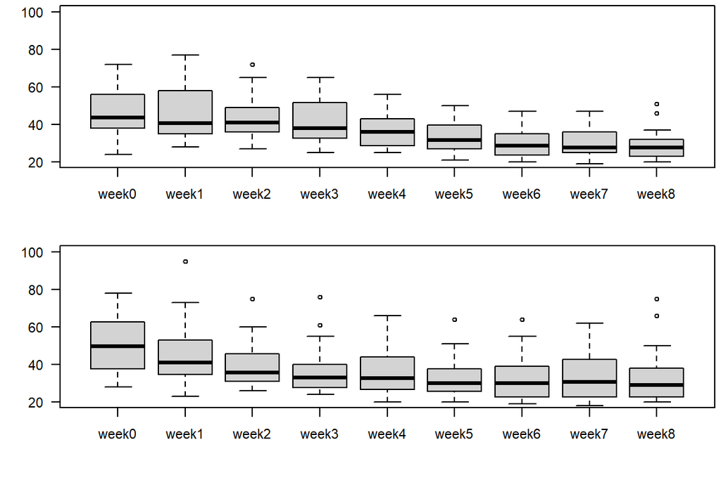

```r
attach(BPRS)
par(mfrow=c(2,1), mai=c(0.6,0.5,0.05,0.05), cex=0.7)
boxplot(BPRS[treatment==1,3:11], ylim=c(20,100), las=1)
boxplot(BPRS[treatment==2,3:11], ylim=c(20,100), las=1)
```

```r
detach(BPRS)
```

BPRS score decreases over time on both treatment groups.

**rats**

```r
rats <- read.csv("https://raw.githubusercontent.com/KimmoVehkalahti/MABS/master/Examples/data/rats.txt", sep  ="\t", header = T)

# dimensions and structure
str(rats)
```

```
## 'data.frame':    16 obs. of  13 variables:
##  $ ID   : int  1 2 3 4 5 6 7 8 9 10 ...
##  $ Group: int  1 1 1 1 1 1 1 1 2 2 ...
##  $ WD1  : int  240 225 245 260 255 260 275 245 410 405 ...
##  $ WD8  : int  250 230 250 255 260 265 275 255 415 420 ...
##  $ WD15 : int  255 230 250 255 255 270 260 260 425 430 ...
##  $ WD22 : int  260 232 255 265 270 275 270 268 428 440 ...
##  $ WD29 : int  262 240 262 265 270 275 273 270 438 448 ...
##  $ WD36 : int  258 240 265 268 273 277 274 265 443 460 ...
##  $ WD43 : int  266 243 267 270 274 278 276 265 442 458 ...
##  $ WD44 : int  266 244 267 272 273 278 271 267 446 464 ...
##  $ WD50 : int  265 238 264 274 276 284 282 273 456 475 ...
##  $ WD57 : int  272 247 268 273 278 279 281 274 468 484 ...
##  $ WD64 : int  278 245 269 275 280 281 284 278 478 496 ...
```

```r
dim(rats)
```

```
## [1] 16 13
```

```r
table(rats$Group)
```

```
##
## 1 2 3
## 8 4 4
```

Data has 16 subjects and 13 variables. Data has 3 treatment groups and subjects are measured 11 times.

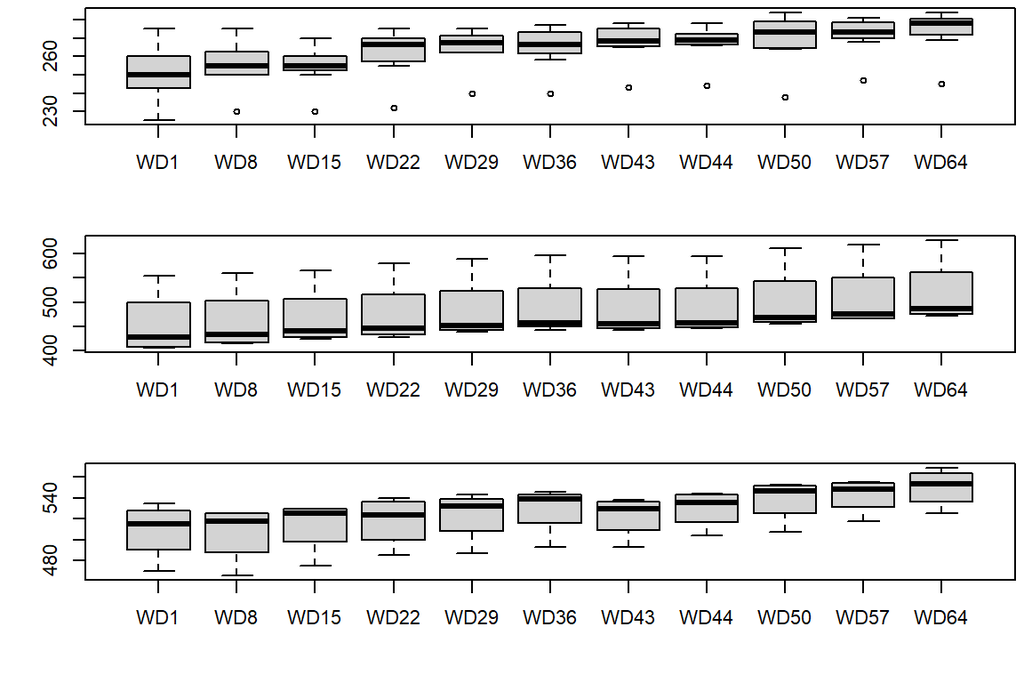

```r
attach(rats)
par(mfrow=c(3,1), mai=c(0.6,0.5,0.05,0.05), cex=0.7)
boxplot(rats[Group==1,3:13])
boxplot(rats[Group==2,3:13])
boxplot(rats[Group==3,3:13])
```

```r
detach(rats)
```

Rats weight is growing over the time on each diet groups. Growth rate seems different.

### 6.1.2 Replace subject indentificator and group variable to factor

```r
BPRS$treatment <- factor(BPRS$treatment)
BPRS$subject <- factor(BPRS$subject)
str(BPRS)
```

```
## 'data.frame':    40 obs. of  11 variables:
##  $ treatment: Factor w/ 2 levels "1","2": 1 1 1 1 1 1 1 1 1 1 ...
##  $ subject  : Factor w/ 20 levels "1","2","3","4",..: 1 2 3 4 5 6 7 8 9 10 ...
##  $ week0    : int  42 58 54 55 72 48 71 30 41 57 ...
##  $ week1    : int  36 68 55 77 75 43 61 36 43 51 ...
##  $ week2    : int  36 61 41 49 72 41 47 38 39 51 ...
##  $ week3    : int  43 55 38 54 65 38 30 38 35 55 ...
##  $ week4    : int  41 43 43 56 50 36 27 31 28 53 ...
##  $ week5    : int  40 34 28 50 39 29 40 26 22 43 ...
##  $ week6    : int  38 28 29 47 32 33 30 26 20 43 ...
##  $ week7    : int  47 28 25 42 38 27 31 25 23 39 ...
##  $ week8    : int  51 28 24 46 32 25 31 24 21 32 ...
```

```r
rats$Group <- factor(rats$Group)
rats$ID <- factor(rats$ID)
str(rats)
```

```
## 'data.frame':    16 obs. of  13 variables:
##  $ ID   : Factor w/ 16 levels "1","2","3","4",..: 1 2 3 4 5 6 7 8 9 10 ...
##  $ Group: Factor w/ 3 levels "1","2","3": 1 1 1 1 1 1 1 1 2 2 ...
##  $ WD1  : int  240 225 245 260 255 260 275 245 410 405 ...
##  $ WD8  : int  250 230 250 255 260 265 275 255 415 420 ...
##  $ WD15 : int  255 230 250 255 255 270 260 260 425 430 ...
##  $ WD22 : int  260 232 255 265 270 275 270 268 428 440 ...
##  $ WD29 : int  262 240 262 265 270 275 273 270 438 448 ...
##  $ WD36 : int  258 240 265 268 273 277 274 265 443 460 ...
##  $ WD43 : int  266 243 267 270 274 278 276 265 442 458 ...
##  $ WD44 : int  266 244 267 272 273 278 271 267 446 464 ...
##  $ WD50 : int  265 238 264 274 276 284 282 273 456 475 ...
##  $ WD57 : int  272 247 268 273 278 279 281 274 468 484 ...
##  $ WD64 : int  278 245 269 275 280 281 284 278 478 496 ...
```

### 6.1.3 Convert to long form, extract time variable as numeric

```r
# Reshape
BPRSL <-  BPRS %>% gather(key = weeks, value = bprs, -treatment, -subject)
head(BPRSL, n=3)
```

```
##   treatment subject weeks bprs
## 1         1       1 week0   42
## 2         1       2 week0   58
## 3         1       3 week0   54
```

```r
str(BPRSL)
```

```
## 'data.frame':    360 obs. of  4 variables:
##  $ treatment: Factor w/ 2 levels "1","2": 1 1 1 1 1 1 1 1 1 1 ...
##  $ subject  : Factor w/ 20 levels "1","2","3","4",..: 1 2 3 4 5 6 7 8 9 10 ...
##  $ weeks    : chr  "week0" "week0" "week0" "week0" ...
##  $ bprs     : int  42 58 54 55 72 48 71 30 41 57 ...
```

```r
# Extract the week number
BPRSL <-  BPRSL %>% mutate(week = as.integer(substr(BPRSL$weeks, 5, 5)))

# Reshape
ratsl <-  rats %>% gather(key = WD, value = weight, -Group, -ID)
str(ratsl)
```

```
## 'data.frame':    176 obs. of  4 variables:
##  $ ID    : Factor w/ 16 levels "1","2","3","4",..: 1 2 3 4 5 6 7 8 9 10 ...
##  $ Group : Factor w/ 3 levels "1","2","3": 1 1 1 1 1 1 1 1 2 2 ...
##  $ WD    : chr  "WD1" "WD1" "WD1" "WD1" ...
##  $ weight: int  240 225 245 260 255 260 275 245 410 405 ...
```

```r
# Extract the week number
ratsl <-  ratsl %>% mutate(Time = as.integer(substr(ratsl$WD, 3, 5)))

# Check results
table(ratsl$WD, ratsl$Time)
```

```
##
##         1  8 15 22 29 36 43 44 50 57 64
##   WD1  16  0  0  0  0  0  0  0  0  0  0
##   WD15  0  0 16  0  0  0  0  0  0  0  0
##   WD22  0  0  0 16  0  0  0  0  0  0  0
##   WD29  0  0  0  0 16  0  0  0  0  0  0
##   WD36  0  0  0  0  0 16  0  0  0  0  0
##   WD43  0  0  0  0  0  0 16  0  0  0  0
##   WD44  0  0  0  0  0  0  0 16  0  0  0
##   WD50  0  0  0  0  0  0  0  0 16  0  0
##   WD57  0  0  0  0  0  0  0  0  0 16  0
##   WD64  0  0  0  0  0  0  0  0  0  0 16
##   WD8   0 16  0  0  0  0  0  0  0  0  0
```

Catecorical WD is now numeric Time. Everything worked!

### 6.1.4 Overview

**rats**

Original data consisted 16 rows (subjects) and 11 timepoints. Each subject had 1 data row. Reshaped data should have 16x11 = 176 rows. Each subject has 11 data row. Data sholed have subject identificator, grouping variable, time variable and weight measure .

Results:

```r
dim(ratsl)
```

```
## [1] 176   5
```

```r
names(ratsl)
```

```
## [1] "ID"     "Group"  "WD"     "weight" "Time"
```

```r
length(table(ratsl$ID))  # still 16 subjects
```

```
## [1] 16
```

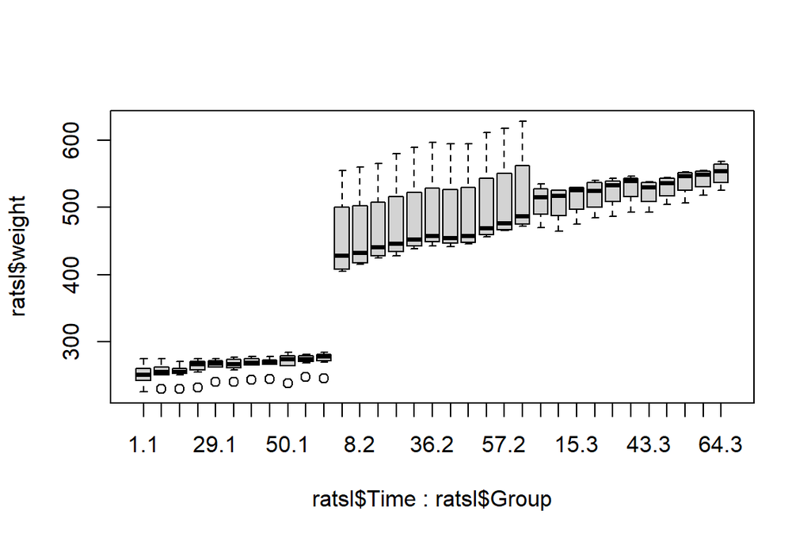

```r
boxplot(ratsl$weight ~ ratsl$Time + ratsl$Group)
```

First diet group has lowest weights, second group has biggest variability on weights and third diet group has highest weihts.

**BPRS**

Original data consisted 40 rows (subjects) and 9 timepoints. Each subject had 1 data row. Reshaped data should have 40x9 = 360 rows. Each subject has 9 data row. Subject IDs are same in both groups (1-20). Data should have subject identificator, grouping variable, time variable and bprs measure .

Results:

```r
dim(BPRSL)
```

```
## [1] 360   5
```

```r
names(BPRSL)
```

```
## [1] "treatment" "subject"   "weeks"     "bprs"      "week"
```

```r
2*length(table(BPRSL$subject))  # still 2x20 subjects
```

```
## [1] 40
```

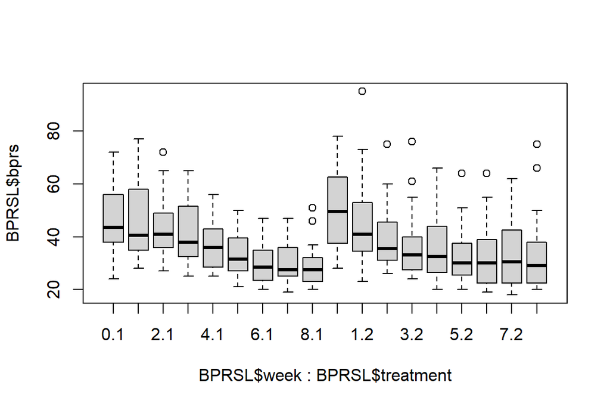

```r
boxplot(BPRSL$bprs ~ BPRSL$week + BPRSL$treatment)
```

BPRS scores decreas on both treatmet groups over time.

Write data to file

```r
write.csv(ratsl, file = (paste0(getwd(), "/data/ratsl.csv")), row.names=T)
write.csv(BPRSL, file = (paste0(getwd(), "/data/bprsl.csv")), row.names=T)
```